# Lab 12: Beyond the General Linear Model

Analysis of Environmental Data

Elyse McCormick

2022-12-08

**Q1 (2 pts.): Include your plot in your lab report.**

```r
require(here)
# Read in data

dat_bird = read.csv(
  here("data", "bird.sub.csv")
)
head(dat_bird)
```

```
##   basin sub tsta AMCR AMDI       AMGO      AMRO    BAEA       BASW       BCCH
## 1     D  AL   35    0    0 0.28571429 0.5428571 0.00000 0.00000000 0.00000000
## 2     D  BC   32    0    0 0.09375000 0.3125000 0.00000 0.00000000 0.00000000
## 3     D  CH   37    0    0 0.05405405 0.5945946 0.00000 0.05405405 0.05405405
## 4     D  DC   34    0    0 0.02941176 0.5588235 0.00000 0.00000000 0.00000000
## 5     D  HC   35    0    0 0.31428571 0.5142857 0.00000 0.00000000 0.08571429
## 6     D  LF   32    0    0 0.53125000 0.4687500 0.03125 0.00000000 0.15625000
##         BEKI       BEWR       BGWA       BHCO      BHGR       BRCR      BTPI
## 1 0.00000000 0.05714286 0.02857143 0.02857143 0.4285714 0.02857143 0.4857143
## 2 0.00000000 0.03125000 0.03125000 0.00000000 0.4062500 0.43750000 0.2500000
## 3 0.05405405 0.02702703 0.08108108 0.00000000 0.7567568 0.37837838 0.8378378
## 4 0.00000000 0.00000000 0.05882353 0.00000000 0.6176471 0.55882353 0.6470588
## 5 0.02857143 0.28571429 0.00000000 0.02857143 0.7142857 0.34285714 0.4000000
## 6 0.00000000 0.25000000 0.12500000 0.03125000 0.8437500 0.28125000 0.5937500
##   BUGR       BUSH       CAGO      CBCH      CEWA COHA      COME       CONI
```

[output cut: 83 more lines]

```r
dat_hab = read.csv(
  here("data", "hab.sub.csv")
)
head(dat_hab)
```

```
##   basin sub sub.lat sub.long sub.elev road.den stream.den     ta p.mps p.tcai
## 1     D  AL 4923007 437086.9      635       19         29 292.17 17.19  25.59
## 2     D  BC 4920180 430610.5      533        1         28 247.91 22.54  16.01
## 3     D  CH 4929243 436373.8      396       11         32 291.08 10.04  11.41
## 4     D  DC 4932834 430564.8      342       18         32 286.92 17.93  18.66
## 5     D  HC 4931820 428852.7      369       30         30 271.44 11.80  20.05
## 6     D  LF 4930588 432246.9      327       34         38 250.09 11.91  18.54
##   p.sidi p.siei p.contag  p.ed p.cwed p.teci s.mps s.tcai s.sidi s.siei
## 1   0.70   0.80    62.97 68.33  16.97  21.83 58.43  62.37   0.12   0.16
## 2   0.63   0.85    47.32 61.59   7.15   9.23 61.98  59.21   0.34   0.50
## 3   0.80   0.87    69.69 72.86  24.67  28.17 22.39  28.33   0.78   0.88
## 4   0.72   0.83    69.42 60.06  20.81  28.89 35.87  33.51   0.57   0.76
## 5   0.84   0.93    70.15 65.46  25.06  30.81 16.97  21.77   0.84   0.94
## 6   0.80   0.87    69.74 76.93  22.67  26.09 25.01  25.51   0.73   0.84
##   s.contag  s.ed s.cwed s.teci    b   ccp ccs    cf   cls  cop  cos csh    g
```

[output cut: 20 more lines]

```r
birdhab <- data.frame(merge(dat_bird, dat_hab))
head(birdhab)
```

```
##   basin sub tsta AMCR AMDI       AMGO      AMRO    BAEA       BASW       BCCH
## 1     D  AL   35    0    0 0.28571429 0.5428571 0.00000 0.00000000 0.00000000
## 2     D  BC   32    0    0 0.09375000 0.3125000 0.00000 0.00000000 0.00000000
## 3     D  CH   37    0    0 0.05405405 0.5945946 0.00000 0.05405405 0.05405405
## 4     D  DC   34    0    0 0.02941176 0.5588235 0.00000 0.00000000 0.00000000
## 5     D  HC   35    0    0 0.31428571 0.5142857 0.00000 0.00000000 0.08571429
## 6     D  LF   32    0    0 0.53125000 0.4687500 0.03125 0.00000000 0.15625000
##         BEKI       BEWR       BGWA       BHCO      BHGR       BRCR      BTPI
## 1 0.00000000 0.05714286 0.02857143 0.02857143 0.4285714 0.02857143 0.4857143
## 2 0.00000000 0.03125000 0.03125000 0.00000000 0.4062500 0.43750000 0.2500000
## 3 0.05405405 0.02702703 0.08108108 0.00000000 0.7567568 0.37837838 0.8378378
## 4 0.00000000 0.00000000 0.05882353 0.00000000 0.6176471 0.55882353 0.6470588
## 5 0.02857143 0.28571429 0.00000000 0.02857143 0.7142857 0.34285714 0.4000000
## 6 0.00000000 0.25000000 0.12500000 0.03125000 0.8437500 0.28125000 0.5937500
##   BUGR       BUSH       CAGO      CBCH      CEWA COHA      COME       CONI
```

[output cut: 111 more lines]

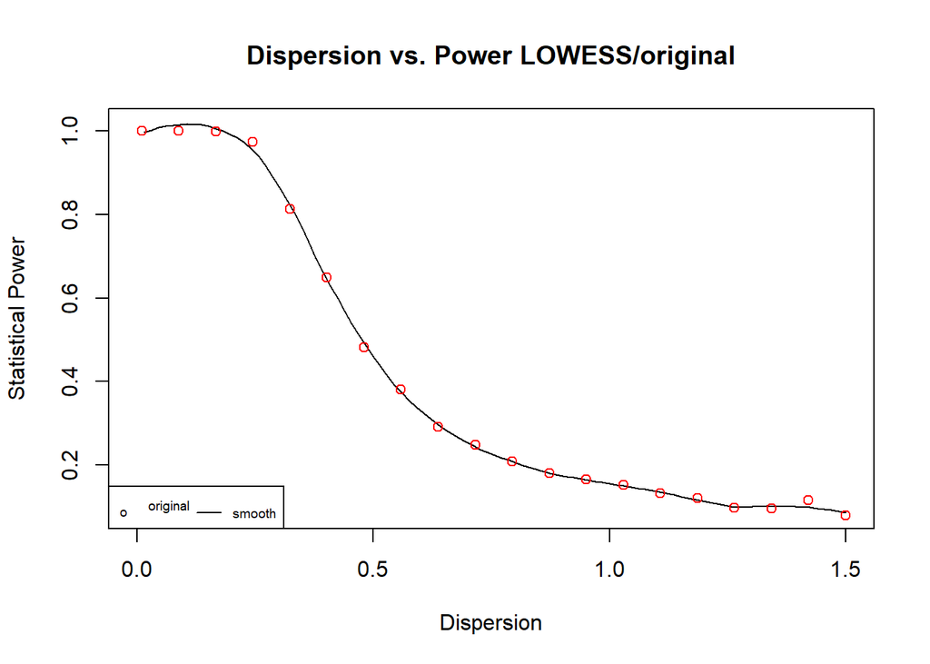

```r
alpha = 0.05
n_sims = 1000
int_obs = 0.0991
slope_obs = 0.00584
sd_obs = 0.1412668

linear = function(x, y_int, slope)
{
      return(y_int + x * slope)
}

linear_simulator = function(x, y_int, slope, st_dev)
{
  y <- linear(x, y_int, slope)
  n <- length(x)
  noise <- rnorm(n, mean = 0, sd = st_dev)

    return(y + noise)
}

linear_sim_fit = function(x, slope, y_int, st_dev)
{
  y_sim = linear_simulator(
    x = x,
    y_int = y_int,
    slope = slope,
    st_dev = st_dev
  )
  fit_sim = lm(y_sim ~ x)
  return(fit_sim)
}

p_vals = numeric(n_sims)

# specify the number of different standard deviation values to simulate:
n_sds = 20
pop_sds = seq(from = 0.01, to = 1.5, length.out = n_sds)

pop_sd_powers = numeric(n_sds)

for(j in 1:n_sds)
{
    for(i in 1:n_sims)
  {
    fit_sim = linear_sim_fit(x = birdhab$ls,
                             y_int = int_obs,
                             slope = slope_obs,
                             st_dev = pop_sds[j])
    p_vals[i] = summary(fit_sim)$coefficients[2, "Pr(>|t|)"]
  }
  pop_sd_powers[j] = sum(p_vals < alpha) / n_sims
}

sim_output_dispersion = data.frame(
  sd = pop_sds,
  power = pop_sd_powers)

fit_lowess_30 = loess(power ~ sd, data = sim_output_dispersion, span = 0.3)
newdata_disp = data.frame(sd = seq(0, 1.5, length.out = 100))
plot(
  x = newdata_disp$sd,
  y = predict(fit_lowess_30, newdata = newdata_disp),
  type = "l",
  ylab = "Statistical Power", xlab = "Dispersion",
  main = "Dispersion vs. Power LOWESS/original"
  )
points(x = sim_output_dispersion$sd, y = sim_output_dispersion$power, col = "red")

legend("bottomleft",
       c("original \n","smooth"),
       lty=c(NA,1),pch=c('o',NA),
       horiz=TRUE, cex=0.6)
```

**Q2 (2 pts.): Include your plot in your lab report.**

```r
require(psych)
```

```r
require(here)
sal_dat = read.csv(here("data", "dispersal.csv"))

plot(sal_dat$dist.class,
     sal_dat$disp.rate.ftb,
     xlim = c(0, 1500),
     xlab = "Distance Class",
     ylab = "Standardized Dispersal Rate",
     main = "Marbled Salamander Dispersal")
ricker_fun = function(x, a, b)
{
  return(a * x * exp(-b * x))
}
curve(
  ricker_fun(x, 0.008, 0.004), from = 0, to = 1500, add = TRUE)

fit_ricker_nls = nls(
  disp.rate.ftb ~ ricker_fun(dist.class, a, b),
  data = sal_dat,
  start = list(b = 0, a = 1))
summary(fit_ricker_nls)
```

```
##
## Formula: disp.rate.ftb ~ ricker_fun(dist.class, a, b)
##
## Parameters:
##   Estimate Std. Error t value Pr(>|t|)
## b 0.003586   0.000913   3.928  0.00201 **
## a 0.004471   0.001889   2.367  0.03558 *
## ---
## Signif. codes:  0 '***' 0.001 '**' 0.01 '*' 0.05 '.' 0.1 ' ' 1
##
## Residual standard error: 0.2149 on 12 degrees of freedom
##
## Number of iterations to convergence: 17
## Achieved convergence tolerance: 9.07e-06
##   (1 observation deleted due to missingness)
```

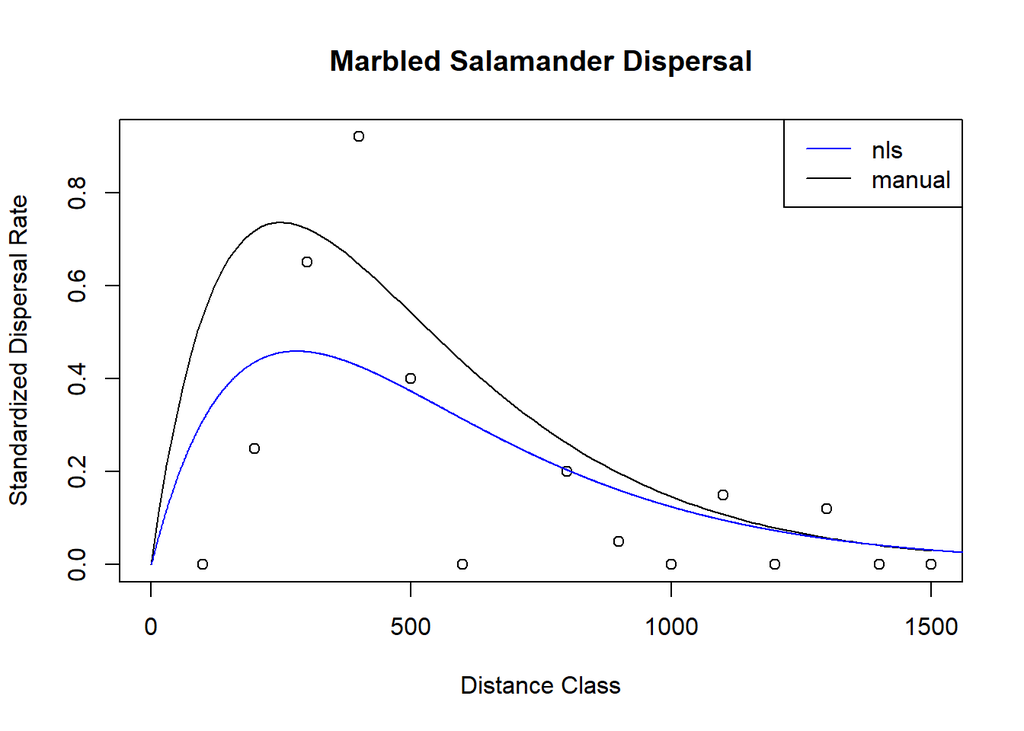

```r
dist_newdata = data.frame(dist.class = seq(0, 1600, length.out = 1600))
lines(predict(fit_ricker_nls, newdata = dist_newdata, ), col = "blue")
legend("topright",
       legend = c("nls", "manual"),
       lty = 1, col = c("blue","black"))
```

**Q3 (1 pt.): What are the AIC values for each of the 4 models?**

```r
#Packages

require(here)

#Import Data

dat_bird = read.csv(here("data", "bird.sta.csv"))
dat_habitat = read.csv(here("data", "hab.sta.csv"))
dat_all = merge(dat_bird, dat_habitat)

dat_all$GCKI_pres = dat_all$GCKI > 0

# Create model fits
fit_GCKI_slope = glm(GCKI_pres ~ slope, data = dat_all, family = binomial)
fit_GCKI_ba_tot = glm(GCKI_pres ~ ba.tot, data = dat_all, family = binomial)
fit_GCKI_both_additive = glm(GCKI_pres ~ slope + ba.tot, data = dat_all, family = binomial)
fit_GCKI_both_interactive = glm(GCKI_pres ~ slope * ba.tot, data = dat_all, family = binomial)

n = 500

slope_newdata = data.frame(
  slope = seq(
    from = min(dat_all$slope, na.rm = T),
    to = max(dat_all$slope, na.rm = T),
    length.out = n
  )
)

ba_newdata = data.frame(
  ba.tot = seq(
    from = min(dat_all$ba.tot, na.rm = T),
    to = max(dat_all$ba.tot, na.rm = T),
    length.out = n
  )
)

slope_newdata$GCKI_predicted =
  predict(
    fit_GCKI_slope,
    newdata = slope_newdata,
    type = "response"
  )

ba_newdata$GCKI_predicted =
  predict(
    fit_GCKI_ba_tot,
    newdata = ba_newdata,
    type = "response"
  )

# Plot parameters

AIC(
  fit_GCKI_ba_tot,
  fit_GCKI_slope,
  fit_GCKI_both_additive,
  fit_GCKI_both_interactive)
```

```
##                           df      AIC
## fit_GCKI_ba_tot            2 1369.379
## fit_GCKI_slope             2 1432.615
## fit_GCKI_both_additive     3 1355.951
## fit_GCKI_both_interactive  4 1353.007
```

**Q4 (1 pt.): Which model would you choose, and why?**

I would choose the model for the Golden Crowned Kinglet with both total basal area and slope interacting (fit_GCKI_both_interactive). Based on it’s low AIC score, that indicates that it is the best fit for the model, and thus the model that best explains the data.

**Q5 (1 pt.): Based on the model coefficient table of your chosen model, describe the direction and significance of the relationship(s) of the predictor variable or variables to the binary response. Make sure your answer is in terms of the ecological context.**

```r
fit_GCKI_both_interactive = glm(GCKI_pres ~ slope * ba.tot, data = dat_all, family = binomial)
summary(fit_GCKI_both_interactive)
```

```
##
## Call:
## glm(formula = GCKI_pres ~ slope * ba.tot, family = binomial,
##     data = dat_all)
##
## Deviance Residuals:
##     Min       1Q   Median       3Q      Max
## -3.7433  -1.0717   0.6444   1.0862   1.4846
##
## Coefficients:
##                Estimate Std. Error z value Pr(>|z|)
## (Intercept)  -0.2643673  0.2500615  -1.057   0.2904
## slope        -0.0040863  0.0045338  -0.901   0.3674
## ba.tot        0.0532974  0.0109776   4.855  1.2e-06 ***
## slope:ba.tot -0.0004131  0.0001866  -2.214   0.0269 *
## ---
## Signif. codes:  0 '***' 0.001 '**' 0.01 '*' 0.05 '.' 0.1 ' ' 1
##
## (Dispersion parameter for binomial family taken to be 1)
##
##     Null deviance: 1439.7  on 1045  degrees of freedom
## Residual deviance: 1345.0  on 1042  degrees of freedom
## AIC: 1353
##
## Number of Fisher Scoring iterations: 4
```

**Q6 (2 pts.): Include your two single-predictor model plots in your report.**

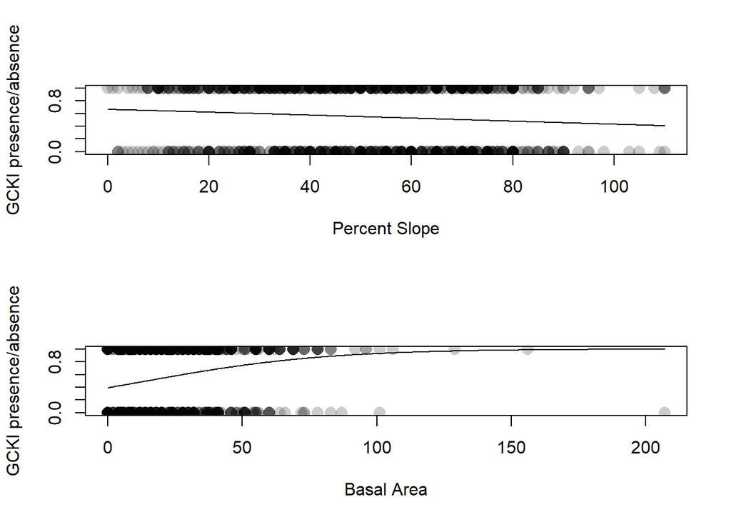

```r
par(mfrow = c(2, 1))

# Presence/absence data, translucent points:
plot(
  GCKI_pres ~ slope, data = dat_all,
  xlab = "Percent Slope",
  ylab = "GCKI presence/absence",
  pch = 16, cex = 1.5, col = gray(0, 0.2)
)

lines(GCKI_predicted ~ slope, data = slope_newdata)

plot(
  GCKI_pres ~ ba.tot, data = dat_all,
  xlab = "Basal Area",
  ylab = "GCKI presence/absence",
  pch = 16, cex = 1.5, col = gray(0, 0.2)
)

lines(GCKI_predicted ~ ba.tot, data = ba_newdata)
```

**Q7 (4 pts.): Include contour plots (or interactive 3D perspective plots) in your report.**

```r
require(rgl)
n = 50

ba.tot = seq(
  from = min(dat_all$ba.tot, na.rm = T),
  to = max(dat_all$ba.tot, na.rm = T),
  length.out = n)
slope = seq(
  from = min(dat_all$slope, na.rm = T),
  to = max(dat_all$slope, na.rm = T),
  length.out = n)

# I can take advantage of the expand.grid() function to make a data.frame
# that contains every combination of the two predictors:

new_dat_all = expand.grid(
  ba.tot = ba.tot,
  slope = slope)
head(new_dat_all)
```

```
##     ba.tot slope
## 1  0.00000     0
## 2  4.22449     0
## 3  8.44898     0
## 4 12.67347     0
## 5 16.89796     0
## 6 21.12245     0
```

```r
tail(new_dat_all)
```

```
##        ba.tot slope
## 2495 185.8776   110
## 2496 190.1020   110
## 2497 194.3265   110
## 2498 198.5510   110
## 2499 202.7755   110
## 2500 207.0000   110
```

```r
new_dat_all$pred_add = predict(
  fit_GCKI_both_additive,
  newdata = new_dat_all,
  type = "response")

z_GCKI_add = matrix(
  new_dat_all$pred_add,
  nrow = length(ba.tot),
  byrow = FALSE)

# Create a color ramp function using heat colors
colorfunc = colorRampPalette(
  heat.colors(length(ba.tot)))

# Figure out the indices of the color ramp
col_indices_GCKI_add = findInterval(
  new_dat_all$pred_add,
  seq(
    min(new_dat_all$pred_add),
    max(new_dat_all$pred_add),
    length.out = 50))

rgl::persp3d(
  x = ba.tot,
  y = slope,
  z = z_GCKI_add,
  xlab = "Basal Area",
  ylab = "Slope",
  zlab = "Pr(present)",
  alpha = 0.9,
  col = colorfunc(50)[col_indices_GCKI_add]
)
rglwidget()
```

[interactive chart not shown]